# Homework 6: Clustering

STAT 253

# Exercises

## Exercise 1: Visualizing structure

### Part a

One variable in the dataset merely *identifies* or *labels* the candies, hence is not a candy *feature*. Convert this to a *row name*, instead of a column.

**Answer**

```r
candy_rankings <- candy_rankings %>%
  column_to_rownames("competitorname") #this add rownames and removes the variable as a column in the dataset (both are important to do)
```

### Part b

Construct a heat map of your (standardized) candy features, setting `Colv = NA`. Use Quarto code chunk options to set your figure width and height to 8.

**Answer**

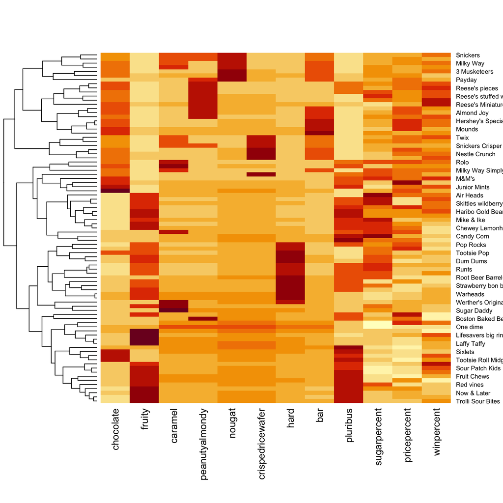

```r
heatmap(data.matrix(scale(candy_rankings)), Colv = NA)
```

### Part c

Construct a dendrogram of your (standardized) candy features using the **complete** linkage method. Use Quarto code chunk options to set your figure width and height to 8.

NOTE: Since all features are quantitative or logical here, do *not* use the `daisy()` function.

**Answer**

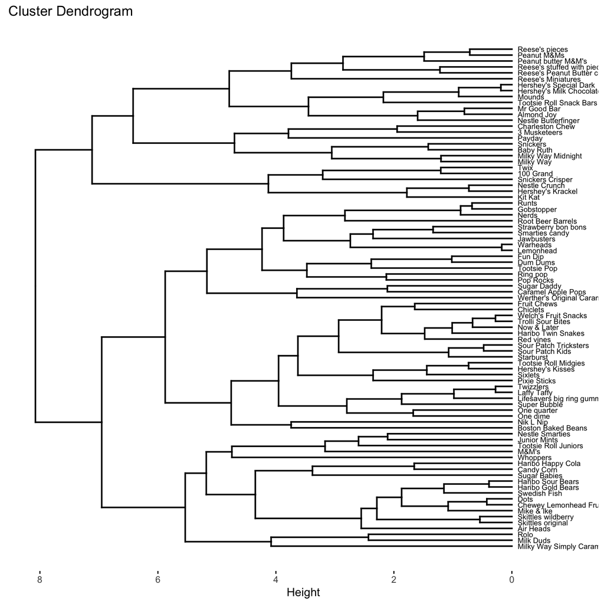

```r
library(cluster)
library(factoextra)
hier_model <- hclust(dist(scale(candy_rankings)), method = "complete")
fviz_dend(hier_model, horiz = TRUE, cex = 0.5)
```

### Part d

How many natural clusters do there appear to be among the candies? There are multiple reasonable answers, and you can give more than 1.

**Answer**

Answers will vary, but 3-4 seems reasonable given the difference in the distance between when clusters are fused around the 6-7 range (“Height” axis).

### Part e

To what other candy are Nik L Nips most similar?

**Answer**

Boston Baked Beans (they are fused together before joining any other cluster)

## Exercise 2: Defining & making meaning from clusters

For the purposes of consistency from student to student, let’s explore the possibility of there being **4** candy clusters.

### Part a

Re-plot your dendrogram, coloring the different leaves and branches according to their cluster assignment. NOTE: There’s built-in code to do this! Use Quarto code chunk options to set your figure width and height to 8.

**Answer**

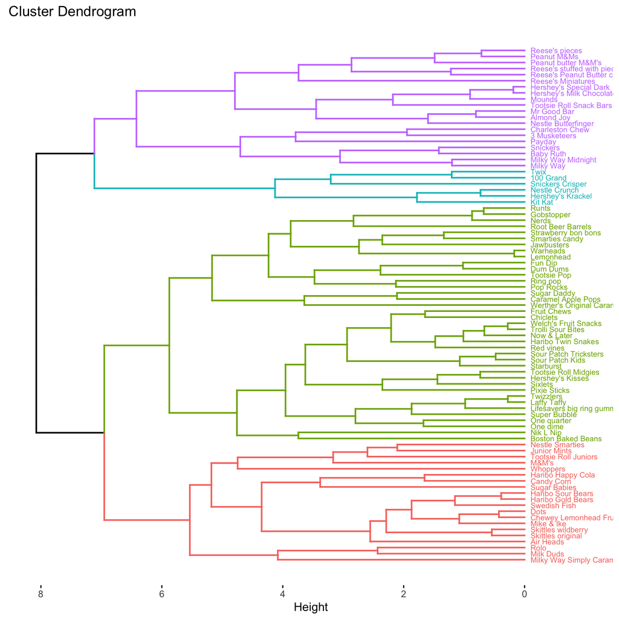

```r
fviz_dend(hier_model, k = 4, horiz = TRUE, cex = 0.5)
```

### Part b

To get a sense for what makes the candies in each cluster “similar”, calculate the mean of each feature within each cluster.

NOTES:

- HINT: First add a column to your dataset which indicates the cluster assignment for each candy. Then `group_by()` and `summarize_all()` (which is like `summarize()` but performs a calculation on *all* columns).
- For TRUE/FALSE features, the mean indicates the proportion of candies that are TRUE.
- LOOKING AHEAD: In a future activity, you’ll be asked to identify appropriate cluster labels and to describe each cluster. Do not write about that yet (your thoughts will evolve throughout the analysis), but start keeping it in mind!

**Answer**

```r
candy_rankings %>%
  mutate(hier_cluster = as.factor(cutree(hier_model, k = 4))) %>%
  group_by(hier_cluster) %>%
  summarize_all(mean)
```

```
# A tibble: 4 × 13
  hier_cluster chocolate fruity caramel peanutyalmondy nougat crispedricewafer
  <fct>            <dbl>  <dbl>   <dbl>          <dbl>  <dbl>            <dbl>
1 1                1      0      0.5            0.167    0                1
2 2                0.95   0      0.2            0.6      0.35             0
3 3                0.103  0.744  0.0769         0.0256   0                0
4 4                0.4    0.45   0.2            0        0                0.05
# ℹ 6 more variables: hard <dbl>, bar <dbl>, pluribus <dbl>,
#   sugarpercent <dbl>, pricepercent <dbl>, winpercent <dbl>
```

### Part c

There’s no “right” number of clusters here! Repeat parts a and b using 3 clusters. How, if at all, does this change your candy insights?

**Answer**

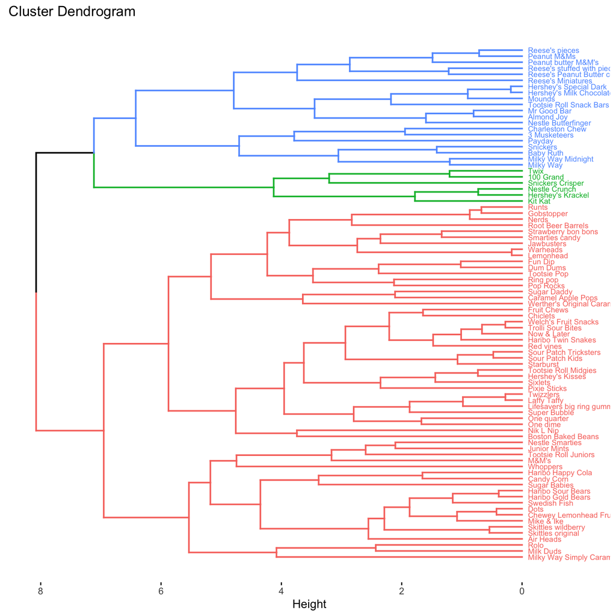

```r
fviz_dend(hier_model, k = 3, horiz = TRUE, cex = 0.5)
```

```r
candy_rankings %>%
  mutate(hier_cluster = as.factor(cutree(hier_model, k = 3))) %>%
  group_by(hier_cluster) %>%
  summarize_all(mean)
```

```
# A tibble: 3 × 13
  hier_cluster chocolate fruity caramel peanutyalmondy nougat crispedricewafer
  <fct>            <dbl>  <dbl>   <dbl>          <dbl>  <dbl>            <dbl>
1 1                1      0       0.5           0.167    0              1
2 2                0.95   0       0.2           0.6      0.35           0
3 3                0.203  0.644   0.119         0.0169   0              0.0169
# ℹ 6 more variables: hard <dbl>, bar <dbl>, pluribus <dbl>,
#   sugarpercent <dbl>, pricepercent <dbl>, winpercent <dbl>
```

The two clusters of non-chocolately candy are now combined into one, so we have two chocolate clusters and one non-chocolate cluster.

## Exercise 3: Sensitivity analysis

Our hierarchical cluster analysis above utilized **complete linkage**.

That is, we measured the distance between two clusters by the *maximum* distance between any pair of candies in those clusters.

This is merely one strategy.

To determine how *sensitive* the clustering algorithm is to our choice of linkage, let’s consider 2 other strategies.

### Part a

Construct a dendrogram using the **centroid linkage** approach (don’t try coloring clusters). Use Quarto code chunk options to set your figure width and height to 8.

Describe how the pattern differs from that of our original complete linkage dendrogram **and** explain why centroid linkage will often produce dendrograms that look like this.

**Answer**

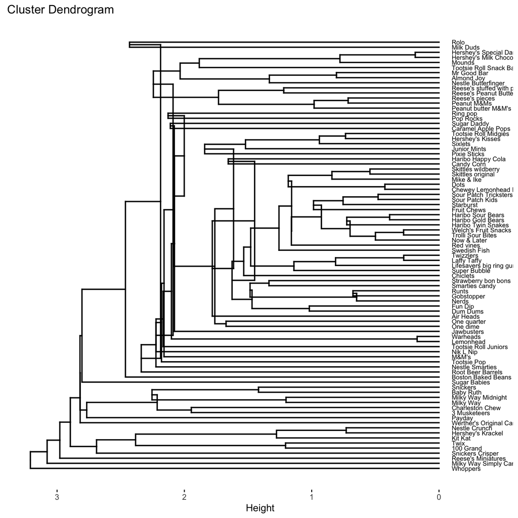

```r
hier_model_centroid <- hclust(dist(scale(candy_rankings)), method = "centroid")
fviz_dend(hier_model_centroid, horiz = TRUE, cex = 0.5)
```

**DESCRIPTION:** Some clusters are inverted – later-merged clusters merged at a lower height.

**EXPLANATION OF WHY THIS HAPPENED:** This happens when the centroids of the later clusters are closer together than the centroids of the earlier centroids.

### Part b

Construct a dendrogram using the **single linkage** approach, *colored by 4 clusters*. Use Quarto code chunk options to set your figure width and height to 8.

Describe how the pattern differs from that of our original complete linkage dendrogram **and** explain why single linkage will often produce dendrograms that look like this.

NOTE: Be sure to not use your cluster assignments from the previous exercise as features in this exercise!

**Answer**

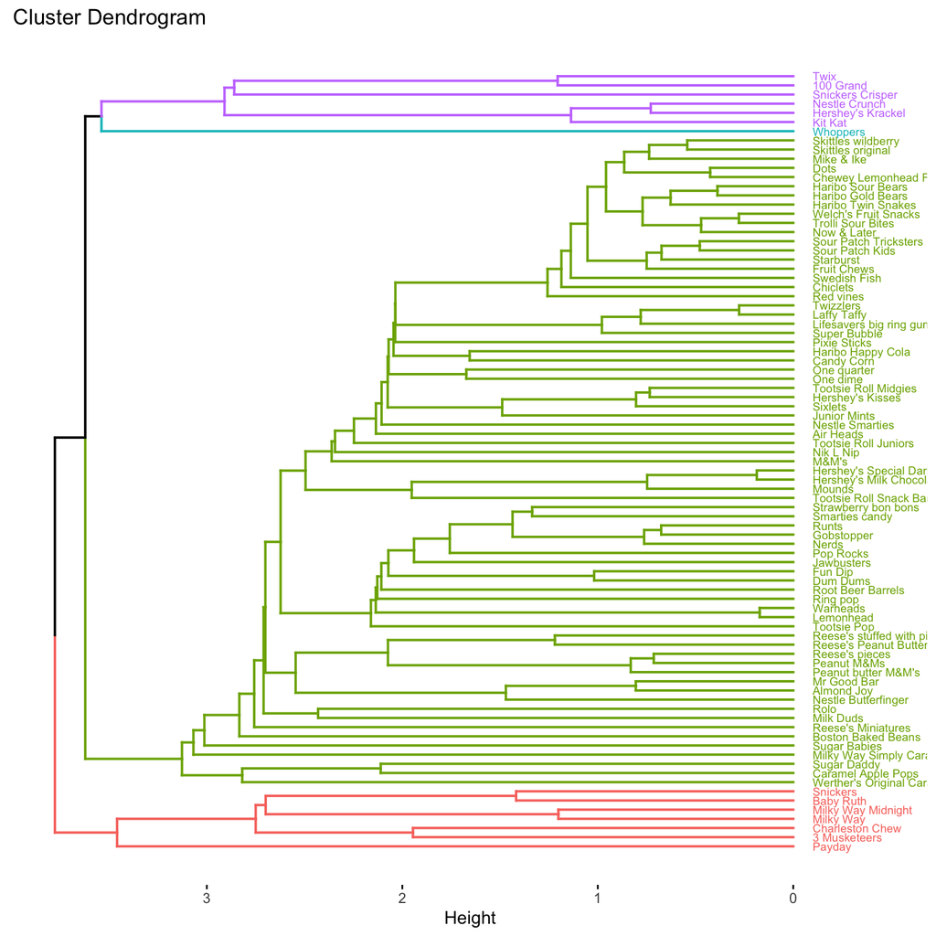

```r
hier_model_single <- hclust(dist(scale(candy_rankings)), method = "single")
fviz_dend(hier_model_single, horiz = TRUE, cex = 0.5, k = 4)
```

**DESCRIPTION:** There’s a long, trailing cluster.

**EXPLANATION OF WHY THIS HAPPENED:** This make sense since candies / clusters can get tacked onto a cluster if they’re close to even *one* candy in that cluster.

### Part c

The appropriate linkage choice depends upon our clustering goals. Suppose we want to identify 4 candy clusters, and want the candies in each cluster to be quite similar. What linkage better suits this goal: complete or single? **Explain.**

**Answer**

**LINKAGE:** complete

**EXPLANATION:** The 2 most different candies in any cluster have to be similar enough. (optional additional detail: in single linkage, a candy might pop into a cluster even if it’s just similar to 1 other candy in that cluster)

### Part d

Suppose we were to cluster Mac students based on their interest in a variety of activities (eg: data, basketball, piano, cooking, etc), and then threw a party for each cluster.

If you were to attend such a party, how would you prefer the clustering do be done, using *complete* or *single* linkage? Justify your choice.

NOTE: There is no wrong answer, but there is wrong justification.

**Answer**

Answers will vary, but the justification should back up the preference.

In general, parties defined using complete linkage would end up with people that have pretty similar interests (the 2 most “different” people at any party would still be similar).  
Parties defined using single linkage would end up with a wider variety of interests – a person needs only be similar to 1 other student to be “invited”.

## Exercise 4: Choosing K

You’ve already run the hierarchical clustering algorithm for the candy data.

Let’s try K-means!

The first step is to **pick K**. So how do we choose?

### Part a

Run and store a K-means algorithm using K = 2. Set the seed to 253 first.

**Answer**

```r
set.seed(253)
kmeans_model <- kmeans(scale(candy_rankings), centers = 2)
```

### Part b

One strategy for evaluating our choice of K is to calculate the total squared distance of each candy from its assigned centroid: the `total within- cluster sum of squares`.

Report this value for your algorithm from part a.

**Answer**

```r
kmeans_model$tot.withinss
```

```
[1] 703.9851
```

### Part c

Next, calculate the total sum of squared distances for each K in 1, 2, …, n where *you* pick a reasonable n. Don’t print them, rather, construct a plot of these distances by K.

**Answer**

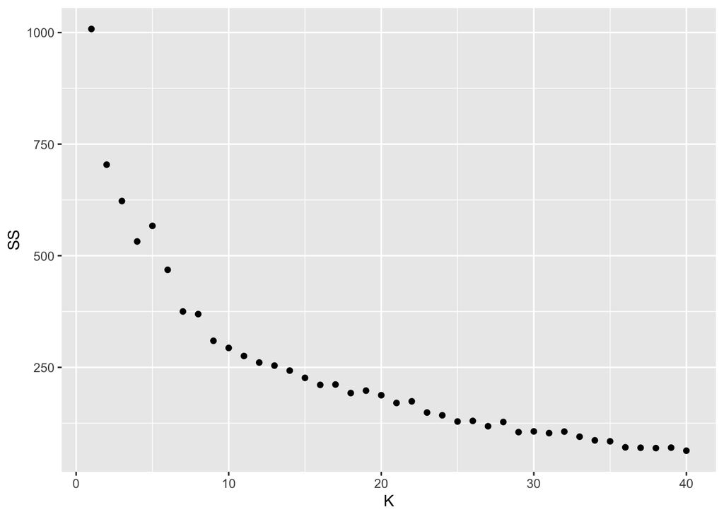

```r
tibble(K = 1:40) %>%
  mutate(SS = map(K, ~ kmeans(scale(candy_rankings), centers = .x)$tot.withinss)) %>%
  unnest(cols = c(SS)) %>%
  ggplot(aes(x = K, y = SS)) +
    geom_point()
```

Notes for graders:

- I picked n = 40. It’s ok if students have something different (they probably will), as long as they tried enough values to see the pattern we’re seeing here (decreasing SS that is starting to level off).
- We’ve seen the first three lines of this code in class. Students just needed to figure out how to translate the output from that code into a plot (ie adding the `ggplot()` commands).

### Part d

Based on this plot, which values of K seem reasonable? **Explain.**

**Answer**

K beween 2 and 15 might all be reasonable answers since this is where we see the steepest decreases in SS and is also not large relative to the number of cases (85 candies) which we’re clustering.

BONUS INFO: If we use silhouette to choose our clusters, we would choose K = 2, which optimizes within cluster variability and the distance between clusters. See below:

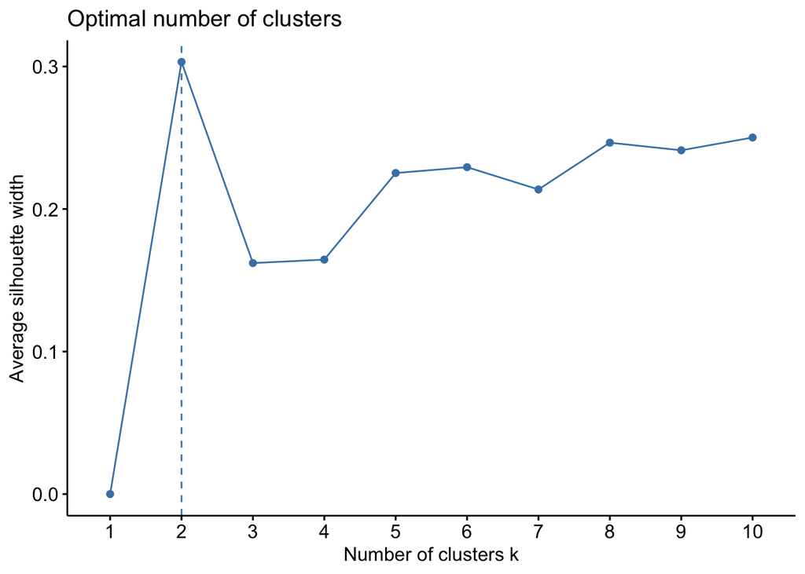

```r
fviz_nbclust(scale(candy_rankings), kmeans, method='silhouette')
```

## Exercise 5: A final K-means model

### Part a

Another strategy for identifying a reasonable number of clusters K for K-means is to do hierarchical clustering, and use the dendrogram to suggest K. Given our earlier choice of using 4 clusters from the dendrogram, run the K-means algorithm using K = 4. Set the seed to 253 first.

**Answer**

```r
set.seed(253)
final_kmeans <- kmeans(scale(candy_rankings), centers = 4)
```

### Part b

To get a sense for what makes the candies in each cluster “similar”, calculate the mean of each feature within each cluster.

**Answer**

```r
candy_rankings %>%
  mutate(cluster_4 = as.factor(final_kmeans$cluster)) %>%
  group_by(cluster_4) %>%
  summarize_all(mean)
```

```
# A tibble: 4 × 13
  cluster_4 chocolate fruity caramel peanutyalmondy nougat crispedricewafer
  <fct>         <dbl>  <dbl>   <dbl>          <dbl>  <dbl>            <dbl>
1 1            0.966   0      0.310          0.448   0.241            0.241
2 2            0.269   0.5    0.0769         0.0385  0                0
3 3            0.0667  0.867  0.0667         0       0                0
4 4            0.0667  0.8    0.133          0       0                0
# ℹ 6 more variables: hard <dbl>, bar <dbl>, pluribus <dbl>,
#   sugarpercent <dbl>, pricepercent <dbl>, winpercent <dbl>
```

## Exercise 6: Final clustering reflection

### Part a

Do your K-means and hierarchical approaches lead to similar conclusions? (What’s the same? What’s different?)

**Answer**

Answers will vary. All are fine as long as the justification is correct!

### Part b

Though K-means is more computationally efficient and less greedy, what’s one pro of hierarchical clustering?

**Answer**

Dendrograms! they’re a nice visual summary. K-means doesn’t have a comparable summary.

### Part c

Bringing it all together across your various hierarchical and K-means clustering outcomes, offer a set of final conclusions. Specifically, write out a label for each final cluster that communicates its unique properties (eg: “big penguins”, “really big penguins”, and “small penguins with long bills”).

NOTE: Focus on the K-means results.

**Answer**

NOTE: The numbers I used below (1,2,3,4) are arbitrary. Students might have these in a different order.

**CLUSTER 1 label:** popular chocolate bars, typically nutty

**CLUSTER 2 label:** miscellaneous / non-descript / pluribus

**CLUSTER 3 label:** hard, fruity candy

**CLUSTER 4 label:** sugary, fruity candy that comes in multiples

## Exercise 7: Resource Reflection

List the resources you used to complete this assignment (e.g. office hours, textbook, Gen AI, etc.)

Write **3-5 sentences** about which resources were the most useful in helping you complete the assignment.

**Answer**

Answers will vary, but students should list the resouces they used to complete this assignment (e.g. office hours, textbook, NOT Gen AI, etc.) and write 3-5 sentences about which resources were the most useful in helping them complete the assignment.